# Lecture 9: Confidence Interval

Mathematics and Statistics BS1515

Theodoros Arvanitopoulos

2025-12-01

# Learning outcomes

### Confidence intervals

- Understand how sample and population are related through statistical inference
- Distinguish between estimator and estimate
- Understand the desired properties of the estimator
- Understand how to (calculate) use confidence intervals and how to interpret them
- Be able to use the t distribution

### 📚 Reading

Newbold et al. (2020), *Statistics for Business and Economics*, Ch. 7

# Estimating an unknown population parameter

A **point estimator** of a population parameter is a sample statistic (i.e. random variable) used to estimate the corresponding population parameter.

A **point** estimate is the value of a point estimator used as an estimate of a population parameter.

→ So, we can estimate a population parameter with a sample statistics, i.e, a point estimate.

*Example*: estimation of the mean weekly wages of graduates in the UK.

*Solution*: One possible estimator of the population mean is the sample mean.

If the mean of a random sample is £800, then £800 is an estimate of the population weekly wages.

# Estimating an unknown population parameter

A **point estimator** of a population parameter is a sample statistic (i.e. random variable) used to estimate the corresponding population parameter.

A **point** estimate is the value of a point estimator used as an estimate of a population parameter.

→ So, we can estimate a population parameter with a sample statistics, i.e, a point estimate.

*Example*: estimation of the mean weekly wages of graduates in the UK.

*Solution*: One possible estimator of the population mean is the sample mean.

If the mean of a random sample is £800, then £800 is an estimate of the population weekly wages.

### Point Estimates and Population Parameters

We can estimate a population parameter with a sample statistic (point estimate):

| Population Parameter |  | Sample Statistic (Point Estimate) |  |
| --- | --- | --- | --- |
| Mean | $\mu$ | Sample Mean | $\bar{x}$ |
| Proportion | $P$ | Sample Proportion | $\hat{p}$ |

# Unbiasedness

A point estimator $\hat{\theta}$ is said to be an unbiased estimator of the population parameter $\theta$ if its expected value is equal to that parameter

$$E(\hat{\theta}) = \theta$$

Examples:

- Sample mean ($\bar{x}$) is an unbiased estimator of population mean ($\mu$)
- Sample variance ($s^2$) is an unbiased estimator of population variance ($\sigma^2$)
- Sample proportion ($\hat{p}$) is an unbiased estimator of population proportion ($P$)

# Unbiasedness

A point estimator $\hat{\theta}$ is said to be an unbiased estimator of the population parameter $\theta$ if its expected value is equal to that parameter

$$E(\hat{\theta}) = \theta$$

Examples:

- Sample mean ($\bar{x}$) is an unbiased estimator of population mean ($\mu$)
- Sample variance ($s^2$) is an unbiased estimator of population variance ($\sigma^2$)
- Sample proportion ($\hat{p}$) is an unbiased estimator of population proportion ($P$)

Example where $\hat{\theta_1}$ is an unbiased estimator of $\theta$, while $\hat{\theta_2}$ is biased

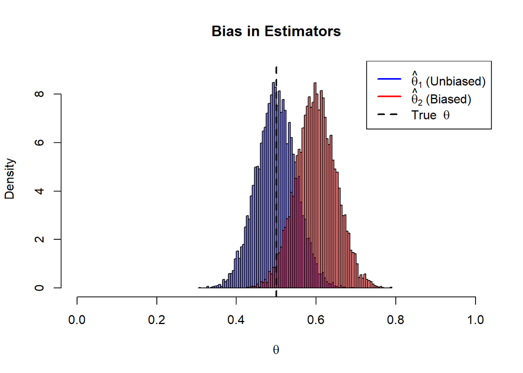

# Bias

Let $\hat{\theta}$ be an estimator of $\theta$

The bias in $\hat{\theta}$ is defined as the difference between its mean and $\theta$

$$Bias(\hat{\theta})=E(\hat{\theta})-\theta$$
So, the bias of an unbiased estimator is 0.

# Efficiency

Suppose there are several unbiased estimators of $\theta$.

The most **efficient estimator** or the **minimum variance unbiased estimator** of $\theta$ is the unbiased estimator with the **smallest variance**

Let $\hat{\theta}_1$ and $\hat{\theta}_2$ be two unbiased estimators of $\theta$, based on the same number of observations:

- $\hat{\theta}_1$ is more efficient than $\hat{\theta}_2$ if $\text{Var}(\hat{\theta}_1)<\text{Var}(\hat{\theta}_2)$
- the relative efficiency of $\hat{\theta}_1$ with respect to $\hat{\theta}_2$ is the ratio of their variances $\frac{Var(\hat{\theta}_2)}{Var(\hat{\theta}_1)}$

# Efficiency

Suppose there are several unbiased estimators of $\theta$.

The most **efficient estimator** or the **minimum variance unbiased estimator** of $\theta$ is the unbiased estimator with the **smallest variance**

Let $\hat{\theta}_1$ and $\hat{\theta}_2$ be two unbiased estimators of $\theta$, based on the same number of observations:

- $\hat{\theta}_1$ is more efficient than $\hat{\theta}_2$ if $\text{Var}(\hat{\theta}_1)<\text{Var}(\hat{\theta}_2)$
- the relative efficiency of $\hat{\theta}_1$ with respect to $\hat{\theta}_2$ is the ratio of their variances $\frac{Var(\hat{\theta}_2)}{Var(\hat{\theta}_1)}$

### Efficiency plot - example

Both $\hat{\theta}_1$ and $\hat{\theta}_2$ are unbiased estimators of the population parameter $\theta$

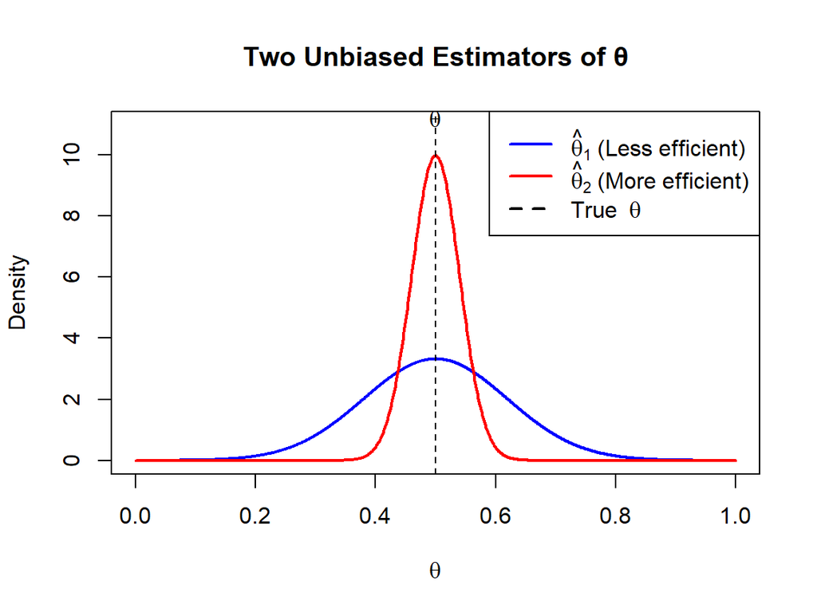

# Confidence intervals

How much uncertainty is associated with a point estimate of a population parameter?

An **interval estimate** provides more information about a population characteristic than does a **point estimate**.

Such interval estimates are called **confidence interval (CI) estimates**, within which we expect the true population parameter to lie.

# Confidence intervals

How much uncertainty is associated with a point estimate of a population parameter?

An **interval estimate** provides more information about a population characteristic than does a **point estimate**.

Such interval estimates are called **confidence interval (CI) estimates**, within which we expect the true population parameter to lie.

### Confidence interval estimation

A interval gives a **range** of values:

- takes into consideration variation in sample statistics from sample to sample
- based on observation from 1 sample
- gives information about closeness to unknown population parameters
- stated in terms of **level of confidence** (one can be 100% confident or less)

# Confidence interval and confidence level

Let $\theta$ be an unknown parameter.

If **$P(a<\theta<b)=1-\alpha$**, where $0 \leq \alpha \leq 1$, then the interval from $a$ to $b$ is called a $100(1-\alpha)\%$ **confidence interval** of $\theta$.

The quantity $100(1-\alpha)\%$ is called the **confidence level** of the interval.

In repeated samples of the population, the true value of the parameter $\theta$ would be contained in $100(1 - \alpha)\%$ of intervals calculated this way.

The confidence interval calculated in this manner is written as $a < \theta < b$ with $100(1 - \alpha)\%$ confidence

# Confidence level $(1-\alpha)$

Suppose confidence level = $95%$, which can also be written as $(1-\alpha)=0.95$.

**A relative frequency interpretation**:

From repeated samples, $95\%$ of all the confidence intervals that can be constructed of size $n$ will contain the unknown true parameter.

A specific interval either will contain or will not contain the true parameter (no probability in specific interval)

**General formula of all confidence intervals** is:

$$\hat{\theta} \pm ME = \text{Point
Estimate} \pm \text{Margin of Error}$$

The value of the margin of error depends on the desired level of confidence

# Confidence interval for $\mu$ ($\sigma^2$ known)

Assumptions:

- Population variance $\sigma^2$ is known
- Population is normally distributed
- If population is not normal, use large sample (CLT)

# Confidence interval for $\mu$ ($\sigma^2$ known)

Assumptions:

- Population variance $\sigma^2$ is known
- Population is normally distributed
- If population is not normal, use large sample (CLT)

**Confidence interval estimate** for the mean is:

$$\bar{x} - z_{\alpha/2}\frac{\sigma}{\sqrt{n}} < \mu < \bar{x}
+ z_{\alpha/2}\frac{\sigma}{\sqrt{n}}$$

where:

- $z_{\alpha/2}$ is the normal distribution value for a probability $\alpha/2$ in each tail
- $\bar{x} - z_{\alpha/2}\frac{\sigma}{\sqrt{n}}$ is the **Lower Confidence Limit (LCL)**
- $\bar{x} + z_{\alpha/2}\frac{\sigma}{\sqrt{n}}$ is the **Upper Confidence Limit (LCL)**
- $z_{\alpha/2}\frac{\sigma}{\sqrt{n}}$ is the **Margin of Error** or **ME**

# Reducing the margin of error and finding $z_{\alpha/2}$

So, the confidence interval can also be written as $\bar{x} \pm ME$ where $ME$ is the **margin of error**

$$ME=z_{\alpha/2}\frac{\sigma}{\sqrt{n}}$$

# Reducing the margin of error and finding $z_{\alpha/2}$

So, the confidence interval can also be written as $\bar{x} \pm ME$ where $ME$ is the **margin of error**

$$ME=z_{\alpha/2}\frac{\sigma}{\sqrt{n}}$$

The margin of error can be reduced if:

- the population standard deviation can be reduced ($\sigma$ ↓) $\rightarrow$ e.g. reduce variability in measurements
- the sample size is increased ($n$ ↑) $\rightarrow$ more information, more precise inference about the mean
- the confidence level is decreased $(1-\alpha)$ ↓ $\rightarrow$ $95\%$ CI shorter than $99\%$ CI

# Reducing the margin of error and finding $z_{\alpha/2}$

So, the confidence interval can also be written as $\bar{x} \pm ME$ where $ME$ is the **margin of error**

$$ME=z_{\alpha/2}\frac{\sigma}{\sqrt{n}}$$

The margin of error can be reduced if:

- the population standard deviation can be reduced ($\sigma$ ↓) $\rightarrow$ e.g. reduce variability in measurements
- the sample size is increased ($n$ ↑) $\rightarrow$ more information, more precise inference about the mean
- the confidence level is decreased $(1-\alpha)$ ↓ $\rightarrow$ $95\%$ CI shorter than $99\%$ CI

Consider a 95% confidence interval:

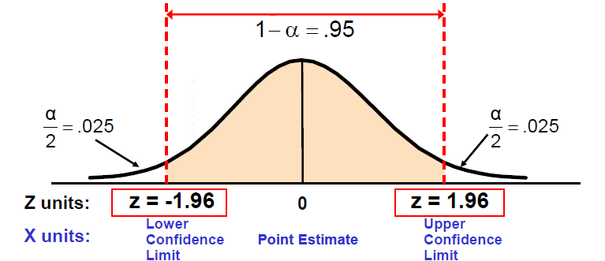

Find $z_{0.025}= \pm 1.96$ from the standard normal distribution table.

# Finding $z_{\alpha/2}$

Find $z_{0.025}= \pm 1.96$ from the standard normal distribution table.

Check the corresponding standard normal distribution table in the textbook appendices (Table 1)

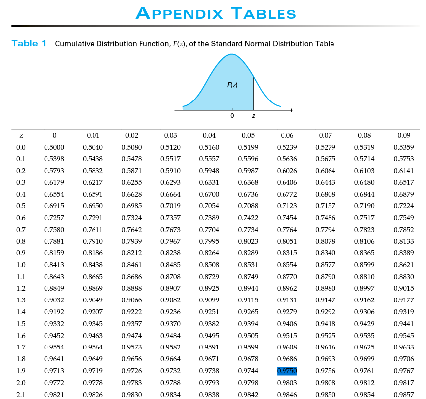

# Common levels of confidence

Commonly used confidence levels are **90%, 95%, and 99%**

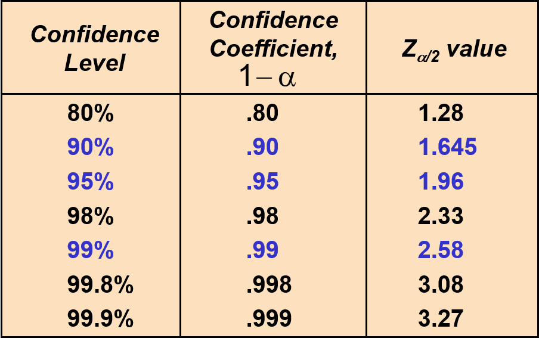

# Example of intervals and level of confidence

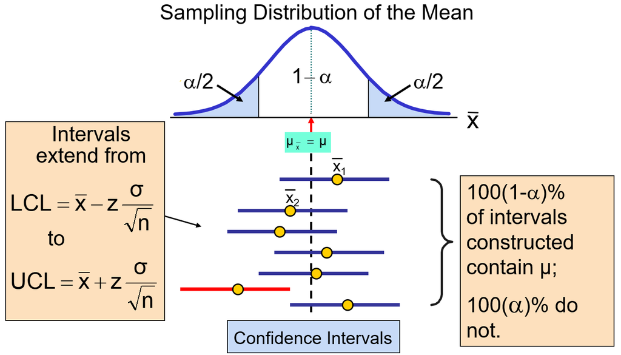

# Confidence intervals for $\mu$ ($\sigma^2$ unknown)

If the population standard deviation $σ$ is unknown, we can substitute the sample standard deviation, $s$.

This introduces extra uncertainty, since $s$ is variable from sample to sample.

So, we use the $t$ distribution instead of the normal distribution.

William Sealey Gosset developed the **Student’s $t$ distribution** in the Guinness Brewery in Dublin.

# Student’s *$t$* Distribution

If the sample mean $\bar{X}$ ~ $N( \mu, \frac{\sigma^2}{n})$ with known population variance $\sigma^2$, then

$$Z= \frac{\bar{X}-\mu}{\sigma_{\bar{x}}} =
\frac{\bar{X}-\mu}{\frac{\sigma}{\sqrt{n}}}$$

# Student’s *$t$* Distribution

If the sample mean $\bar{X}$ ~ $N( \mu, \frac{\sigma^2}{n})$ with known population variance $\sigma^2$, then

$$Z= \frac{\bar{X}-\mu}{\sigma_{\bar{x}}} =
\frac{\bar{X}-\mu}{\frac{\sigma}{\sqrt{n}}}$$

Now, consider a random sample of $n$ observations

- with mean $\bar{x}$ and standard deviation $s$
- from a normally distributed population with mean $\mu$

# Student’s *$t$* Distribution

If the sample mean $\bar{X}$ ~ $N( \mu, \frac{\sigma^2}{n})$ with known population variance $\sigma^2$, then

$$Z= \frac{\bar{X}-\mu}{\sigma_{\bar{x}}} =
\frac{\bar{X}-\mu}{\frac{\sigma}{\sqrt{n}}}$$

Now, consider a random sample of $n$ observations

- with mean $\bar{x}$ and standard deviation $s$
- from a normally distributed population with mean $\mu$

So, if the sample mean $\bar{X}$ ~ $N( \mu, \frac{\sigma^2}{n})$ with unknown population variance $\sigma^2$, then

$$t= \frac{\bar{x}-\mu}{\frac{s}{\sqrt{n}}}$$
which follows the **Student’s *$t$* Distribution** with $\nu$ degrees of freedom

# Student’s *$t$* Distribution - confidence intervals

Assumptions:

- Population standard deviation is unknown
- Population is normally distributed
- If population is not normal, use large sample (CLT)

# Student’s *$t$* Distribution - confidence intervals

Assumptions:

- Population standard deviation is unknown
- Population is normally distributed
- If population is not normal, use large sample (CLT)

Then, we use the **Student’s *$t$* Distribution** with confidence interval estimates:

$$\bar{x} - t_{n-1, \ \alpha/2} \frac{s}{\sqrt{n}} < \mu < \bar{x} +
t_{n-1, \ \alpha/2} \frac{s}{\sqrt{n}}$$
where:

- $t_{n-1, \ \alpha/2}$ is the critical value of the t distribution with $n-1$ d.f. and an area $\alpha/2$ in each tail
- $\bar{x} - t_{n-1, \ \alpha/2} \frac{s}{\sqrt{n}}$ is the **Lower Confidence Limit (LCL)**
- $\bar{x} + t_{n-1, \ \alpha/2} \frac{s}{\sqrt{n}}$ is the **Upper Confidence Limit (LCL)**
- $t_{n-1, \ \alpha/2} \frac{s}{\sqrt{n}}$ is the **Margin of Error** or **ME**

# Student’s *$t$* Distribution

The $t$ is a family of distributions.

The $t$ value depends on **degrees of freedom (d.f.)**, which is the number of observations that are free to vary after the sample mean has been calculated:

$$d.f.=n-1$$

$t$ → $Z$ as $n$ increases

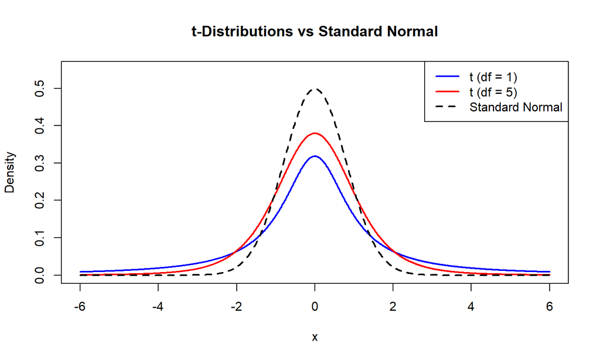

$t$ distributions are bell shaped and symmetric, but have ‘fatter’ tails than the normal distribution (with infinite d.f.)

# Student’s *$t$* Distribution

Critical Values for t Distribution (95% CI)

| Degrees of Freedom | t-value (α/2) for 95% CI |
| --- | --- |
| 5 | 2.571 |
| 10 | 2.228 |
| 15 | 2.131 |
| 20 | 2.086 |
| 25 | 2.060 |
| 30 | 2.042 |

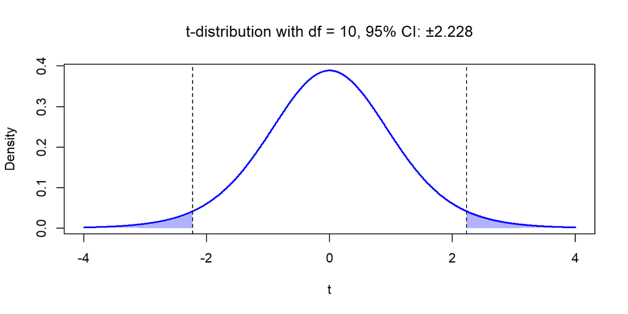

# Confidence intervals for population proportion

An interval estimate for the population proportion $P$ can be calculated by adding an allowance for uncertainty to the sample proportion $\hat{p}$

The distribution of the sample proportion is approximately normal if the sample size is large, with standard deviation

$$\sigma_P=\sqrt{\frac{P(1-P)}{n}}$$

and we estimate this with sample data $\sqrt{\frac{\hat{p}(1-\hat{p})}{n}}$

# Confidence intervals for population proportion

An interval estimate for the population proportion $P$ can be calculated by adding an allowance for uncertainty to the sample proportion $\hat{p}$

The distribution of the sample proportion is approximately normal if the sample size is large, with standard deviation

$$\sigma_P=\sqrt{\frac{P(1-P)}{n}}$$

and we estimate this with sample data $\sqrt{\frac{\hat{p}(1-\hat{p})}{n}}$

The confidence interval for population proportion is given by

$$\hat{p} \pm z_{\alpha/2}\sqrt{\frac{\hat{p}(1-\hat{p})}{n}}$$

where:

- $z_{\alpha/2}$ is the standard normal value for the level of confidence desired
- $\hat{p}$ is the sample proportion and $n$ is the sample size
- $z_{\alpha/2}\sqrt{\frac{\hat{p}(1-\hat{p})}{n}}$ is the Margin of Error
- $nP(1-P) > 5$